# Tutorial on Pivot Tables and other Excel things you can also do in R - Witch Trials data

by Kim Fitter

## Introduction

This tutorial was inspired by the [R Curious tutorial at useR! 2018](https://user2018.r-project.org/tutorials/), and follows on thematically from the R Curious workshop [notes](https://github.com/softloud/rcurious/tree/master/workshop).

It is aimed at those with a background in Excel, who would also like to use R for data analysis. This tutorial compares the things you would normally do in Excel, but with an equivalent function in R.

This introductory level tutorial assumes you have already installed R and R studio and had a brief introduction to the R basics and R Markdown.

From the [R Markdown](https://github.com/kimnewzealand/R-tutorials/blob/master/excel-extensions-which-witch.Rmd) run each line of code (Ctrl + Enter) or code chunk (Ctrl + Shift +Enter) yourself or Knit -> Knit to HTML to read through the HTML version.

## Particularly useful packages for this exercise

```r
# Load packages
library(tidyverse)
library(rpivotTable)
```

**Tip** Install the package from CRAN the first time you use the package using `install.packages("name of package")` else you will get an `Error` that there is no package.

**Tip** The latest package version is sometimes available from GitHub so alternatively install from GitHub using the`devtools` package. A package’s GitHub README file typically has installation instructions.

## Import Witch Trial data

The dataset used in this tutorial is of 43,000 people tried for witchcraft across 21 European countries over a period of five-and-a-half centuries used for this [economic journal](https://www.researchgate.net/publication/315533575_Witch_Trials).

This is what the csv file looks like in Excel:

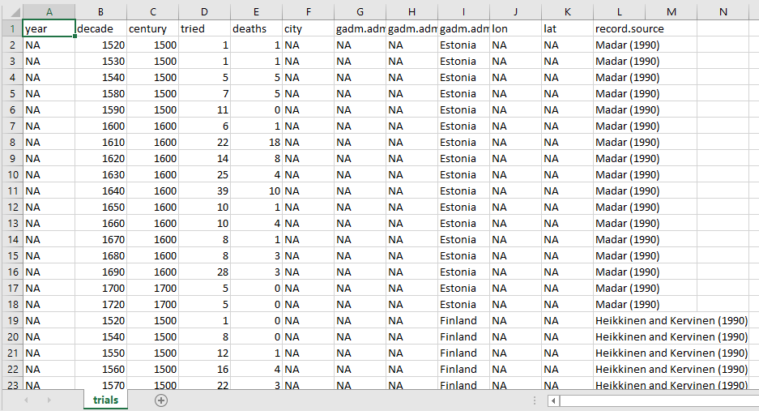

In R, import the data using the `read_csv` function from the [readr](https://cran.r-project.org/web/packages/readr/index.html) R package which is loaded with the tidyverse, to import the raw data to a data frame called `witchdat`.

A data frame, which is a 2-dimensional object where contents can be different data types.

```r
# Download raw data from the author's GitHub url https://github.com/JakeRuss/witch-trials/tree/master/data
url <- "https://raw.githubusercontent.com/JakeRuss/witch-trials/master/data/trials.csv"
# The read_csv function also produces default messages describing the parsing of columns which is converting the columns into different types.
witchdat <- read_csv(url)
```

Let’s take a quick look at the `witchdat` data frame in R to get an idea of it’s size and contents.

In R there are some packages that are included by default; take a look at the packages available in the Global Environment drop down. One such package is called [base](https://stat.ethz.ch/R-manual/R-devel/library/base/html/00Index.html) which includes dim function to retrieve the dimensions, the row and column numbers.

```r
# Retrieve the number of rows and columns
dim(witchdat)
```

```
## [1] 10940    12
```

Another included package is [utils](https://cran.r-project.org/web/packages/R.utils/index.html) R package which includes the `str` and `structure` functions to view the basic structure.

```r
# Use str function to 'Compactly Display the Structure of an Arbitrary R Object'. All R objects store additional attributes to store metadata about an object. In this str function we set the give.attr to FALSE to exclude these attributes.
str(witchdat, give.attr=FALSE)
```

```
## Classes 'tbl_df', 'tbl' and 'data.frame':    10940 obs. of  12 variables:
##  $ year         : int  NA NA NA NA NA NA NA NA NA NA ...
##  $ decade       : int  1520 1530 1540 1580 1590 1600 1610 1620 1630 1640 ...
##  $ century      : int  1500 1500 1500 1500 1500 1600 1600 1600 1600 1600 ...
##  $ tried        : int  1 1 5 7 11 6 22 14 25 39 ...
##  $ deaths       : int  1 1 5 5 0 1 18 8 4 10 ...
##  $ city         : chr  NA NA NA NA ...
##  $ gadm.adm2    : chr  NA NA NA NA ...
##  $ gadm.adm1    : chr  NA NA NA NA ...
##  $ gadm.adm0    : chr  "Estonia" "Estonia" "Estonia" "Estonia" ...
##  $ lon          : num  NA NA NA NA NA NA NA NA NA NA ...
##  $ lat          : num  NA NA NA NA NA NA NA NA NA NA ...
##  $ record.source: chr  "Madar (1990)" "Madar (1990)" "Madar (1990)" "Madar (1990)" ...
```

```r
# Next we will use structure function to view witchdat
structure(witchdat)
```

```
## # A tibble: 10,940 x 12
##     year decade century tried deaths city  gadm.adm2 gadm.adm1 gadm.adm0
##    <int>  <int>   <int> <int>  <int> <chr> <chr>     <chr>     <chr>
##  1    NA   1520    1500     1      1 <NA>  <NA>      <NA>      Estonia
##  2    NA   1530    1500     1      1 <NA>  <NA>      <NA>      Estonia
##  3    NA   1540    1500     5      5 <NA>  <NA>      <NA>      Estonia
##  4    NA   1580    1500     7      5 <NA>  <NA>      <NA>      Estonia
##  5    NA   1590    1500    11      0 <NA>  <NA>      <NA>      Estonia
##  6    NA   1600    1600     6      1 <NA>  <NA>      <NA>      Estonia
##  7    NA   1610    1600    22     18 <NA>  <NA>      <NA>      Estonia
##  8    NA   1620    1600    14      8 <NA>  <NA>      <NA>      Estonia
##  9    NA   1630    1600    25      4 <NA>  <NA>      <NA>      Estonia
## 10    NA   1640    1600    39     10 <NA>  <NA>      <NA>      Estonia
## # ... with 10,930 more rows, and 3 more variables: lon <dbl>, lat <dbl>,
## #   record.source <chr>
```

```r
# There are other ways of looking at your data. Try the glimpse function from the tibble package. Take a look at the Help description with ?glimpse to find out more
glimpse(witchdat)
```

```
## Observations: 10,940
## Variables: 12
## $ year          <int> NA, NA, NA, NA, NA, NA, NA, NA, NA, NA, NA, NA, ...
## $ decade        <int> 1520, 1530, 1540, 1580, 1590, 1600, 1610, 1620, ...
## $ century       <int> 1500, 1500, 1500, 1500, 1500, 1600, 1600, 1600, ...
## $ tried         <int> 1, 1, 5, 7, 11, 6, 22, 14, 25, 39, 10, 10, 8, 8,...
## $ deaths        <int> 1, 1, 5, 5, 0, 1, 18, 8, 4, 10, 1, 4, 1, 3, 3, 0...
## $ city          <chr> NA, NA, NA, NA, NA, NA, NA, NA, NA, NA, NA, NA, ...
## $ gadm.adm2     <chr> NA, NA, NA, NA, NA, NA, NA, NA, NA, NA, NA, NA, ...
## $ gadm.adm1     <chr> NA, NA, NA, NA, NA, NA, NA, NA, NA, NA, NA, NA, ...
## $ gadm.adm0     <chr> "Estonia", "Estonia", "Estonia", "Estonia", "Est...
## $ lon           <dbl> NA, NA, NA, NA, NA, NA, NA, NA, NA, NA, NA, NA, ...
## $ lat           <dbl> NA, NA, NA, NA, NA, NA, NA, NA, NA, NA, NA, NA, ...
## $ record.source <chr> "Madar (1990)", "Madar (1990)", "Madar (1990)", ...
```

This is a fairly large data frame with columns that are characters, doubles and integers.